# Modelling

Applied introduction with `tidymodels`

Last session we talked a bit about how you might scrape data from the web. Collecting data is not an end in itself, rather the first step in answering your research question. When it comes to analyzing trends, testing hypotheses, and predicting outcomes, modelling enters the picture.

In general, remember that your basic workflow for evaluating and reporting models is as follows:

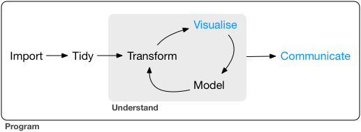

Today we will mostly deal with the “Model” and “Communicate” steps shown in the graph.

To that end, we will cover:

- the basic intuition of how prediction models are set up and trained,
- how to train and evaluate a prediction model in `R`,
- how `tidymodels` can be used to make this process more efficient and robust,
- how to report models, using regression tables and plots.

This lab focuses on the “mechanics” of modelling. In practice, justifying which model to use (and interpreting the model) is arguably much more important than what we cover today. These aspects will be discussed at length in your future Machine Learning and Causal Inference courses, and in a lot of electives. Those of you who took Statistics II will already be familiar with some of these considerations.

# Setup

We again use the `flights` data from the [`nycflights13`](https://nycflights13.tidyverse.org/) package, containing flights that departed from New York City in 2013.

```r
library(tidyverse)
library(nycflights13)
```

The full dataset contains more than 300,000 flights. To minimize the time our models run, we take a sample of 20,000 flights with a recorded arrival delay and retain a small set of possible predictors.

`slice_sample` samples randomly from the input dataframe. Whenever your code involves randomness, it is important to explicitly set a `seed` - the concrete value does not matter, just that it’s constant. This will keep your code reproducible for you and your colleagues.

```r
set.seed(2026)

flights_dat <- nycflights13::flights |>
  dplyr::filter(!is.na(arr_delay)) |>
  dplyr::select(
    arr_delay, dep_delay, distance, origin, carrier
  ) |>
  tidyr::drop_na() |>
  dplyr::mutate(
    origin = factor(origin),
    carrier = factor(carrier)
  ) |>
  dplyr::slice_sample(n = 20000)

dplyr::glimpse(flights_dat)
```

```
## Rows: 20,000
## Columns: 5
## $ arr_delay <dbl> -32, 36, 5, -34, 7, -17, 0, 142, 53, -11, -18, -15, -30, 14,…
## $ dep_delay <dbl> -2, 32, 37, -12, -2, -6, -2, 113, 66, 6, 3, -9, -2, 28, 89, …
## $ distance  <dbl> 1325, 1020, 1008, 187, 944, 2446, 419, 872, 762, 529, 1428, …
## $ origin    <fct> EWR, LGA, EWR, JFK, JFK, JFK, LGA, EWR, LGA, EWR, JFK, JFK, …
## $ carrier   <fct> EV, DL, DL, 9E, B6, B6, MQ, WN, MQ, US, B6, B6, B6, EV, UA, …
```

In general, we can use models in two different ways:

- to test hypothesis, aka answering causal questions about our data
- to create predictions from the data, aka to learn the underlying data generating process.

Today, we will exclusively focus on the latter aspect of modeling, trying to **predict a flights arrival delay**.

All models we build during this lab are intended to be examples in order to get used to the workflow - we are not too concerned with building the best possible model or even models suitable for real-world use.

# Modelling with usual R functions

First, we build the complete prediction pipeline with the tools that come with R and the `tidyverse` data-wrangling functions you already know. Once we build an intuition of the basic workflow, we will see how we can make our lives easier using the packages bundled in `tidymodels`.

A prediction model learns a rule that maps a set of **predictors** to an **outcome**. Here, the outcome is `arr_delay` - it is was we want to predict. The predictors are what the model can use to predict the outcome.

Building a prediction model generally has two phases:

1. **Fitting** or **training** the model: Here, the model learns how to calculate the outcome based on the predictors. This usually means solving an optimization problem. For example, in OLS-regression, the model will calculate the set of regression coefficients that minimize the squared error. The prediction error is the difference between the value a model predicts and the true (known) outcome value.
2. **Testing** or **evaluating** the model: Here, we present the trained model some data that it has not yet seen and again check how close our predictions are to the true outcome value.

When building prediction models, we want to make sure that our model actually learned the *general idea* of the function connecting the predictors to the outcome. **We don’t want our model to just memorize all the data** - instead, it should also give reasonable predictions when presented with data it has never seen before.

## 1. Split the data

We must evaluate predictions on observations that were not used to estimate the model. We therefore randomly assign 80% of the flights to a training set and reserve 20% as a test set. 80/20 is a common ratio between training and testing data.

```r
# Get indices representing 80% of the data.
train_rows <- sample(
  seq_len(nrow(flights_dat)),
  size = floor(0.80 * nrow(flights_dat))
)

# Lookup train and test set based on the indices
flights_train <- flights_dat |>
  dplyr::slice(train_rows)

flights_test <- flights_dat |>
  dplyr::slice(-train_rows)
```

From this point onward, the test set is not used train the model. It is only used to evaluate the finished prediction rule, aka the fitted model.

## 2. Specify and fit the model

Specifying a model involves writing down what relationship you expect between your outcome and your predictors. In R, we use **formulas** to specify these relationships.

The basic structure of a formula looks like this: `y ~ x`.

On the left side, we denote our outcome. On the right side come the predictors. In the simple case above, the formula says: Calculate `y` on basis of `x`. In OLS-regression, this calculation involves one regression coefficient for each predictor on the right side, and an intercept.

To fit a linear regression (OLS) model in R, we use the `lm` function. It takes the formula for our model and the data it should fit as parameters:

```r
flight_formula <-
  arr_delay ~ dep_delay + distance + origin + carrier

lm_fit <- stats::lm(
  formula = flight_formula,
  data = flights_train # We fit the model only on the training data!
)

lm_fit
```

```
##
## Call:
## stats::lm(formula = flight_formula, data = flights_train)
##
## Coefficients:
## (Intercept)    dep_delay     distance    originJFK    originLGA    carrierAA
##   -8.109567     1.023730    -0.000905    -1.730716    -0.518140     1.975513
##   carrierAS    carrierB6    carrierDL    carrierEV    carrierF9    carrierFL
##    0.391302     7.138104     1.647840     4.374293     9.217038    12.578707
##   carrierHA    carrierMQ    carrierOO    carrierUA    carrierUS    carrierVX
##   13.937044     9.664667    18.554975     1.552290     7.335050    -0.811168
##   carrierWN    carrierYV
##    0.525701     5.206037
```

The fitted coefficients describe the prediction rule. For a new flight, R multiplies each predictor by its fitted coefficient and adds the intercept.

## 3. Predict new observations

`predict()` applies the fitted rule to the predictors in `flights_test`. We keep the observed arrival delay alongside each prediction so that we can calculate the prediction errors: As already mentioned, that is the **difference between the true outcome and our prediction**.

```r
test_predictions <- flights_test |>
  dplyr::select(arr_delay) |>
  dplyr::mutate(
    .pred = stats::predict(
      lm_fit, # Fitted Model
      newdata = flights_test # Attention: for predicting, use the test data!
    ),
    .error = arr_delay - .pred # Specify how to calculate prediction error
  )

dplyr::slice_head(test_predictions, n = 6)
```

```
## # A tibble: 6 × 3
##   arr_delay  .pred  .error
##       <dbl>  <dbl>   <dbl>
## 1         7  -5.60  12.6
## 2        -8  -4.66  -3.34
## 3        -8  -8.14   0.140
## 4       -33 -15.0  -18.0
## 5         0  -7.33   7.33
## 6        -1  -1.50   0.503
```

The model nearly perfectly predicted some values! For others, it predicted values either too small or too large. Next, we will see how to systematically assess how good our model was, taking into account all of the data in our test set.

## 4. Evaluate the predictions

There are many different metrics on which you can evaluate how good a model is. Which ones to use depends on the precise task the model should solve. We will use three metrics which are very common for numerical prediction problems:

- **MAE**, the **mean absolute error**: Calculates the average distance between the prediction and the true value. Lower values are better.
- **RMSE**, the **root-mean-square-error**: Calculates the root of the average of the squared errors. It is more sensitive to outliers, as larger errors have a higher impact due to the squaring. Lower values are better.
- **R-squared** describes how much of the variance in the true outcome value is captured by our model. Values are between 0 (the model captures no variance) and 1 (perfect, the model captures all variance).

```r
metrics <- tibble::tibble(
  .metric = c("mae", "rmse", "rsq"),
  .estimate = c(
    mean(abs(test_predictions$.error)),
    sqrt(mean(test_predictions$.error^2)),
    cor(
      test_predictions$arr_delay,
      test_predictions$.pred
    )^2
  )
)

metrics
```

```
## # A tibble: 3 × 2
##   .metric .estimate
##   <chr>       <dbl>
## 1 mae        13.2
## 2 rmse       18.1
## 3 rsq         0.848
```

Whether for example 12 for the MAE is high or not requires us to know the scale of the original data. If the maximum value of the outcome in the data is 5, an MAE of 12 would be quite bad. If most values would be in the thousands, 12 is a pretty small error.

Let’s take a look at a plot common to evaluate this, plotting our predictions against the true values:

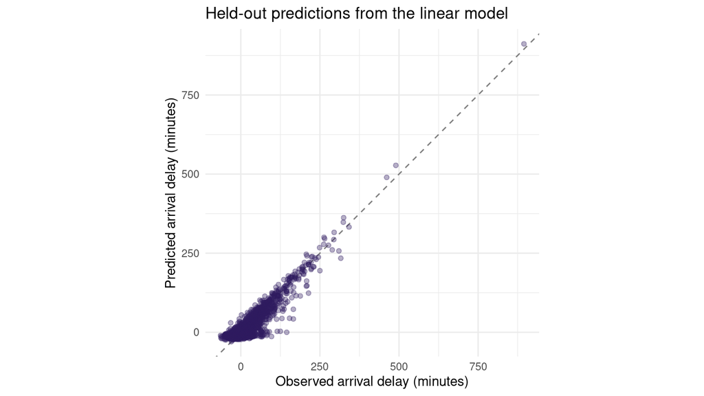

```r
test_predictions |>
  ggplot2::ggplot(ggplot2::aes(x = arr_delay, y = .pred)) +
  ggplot2::geom_abline(
    slope = 1,
    intercept = 0,
    linetype = "dashed",
    colour = "grey50"
  ) +
  ggplot2::geom_point(alpha = 0.35, colour = "#2f1a61") +
  ggplot2::coord_equal() +
  ggplot2::labs(
    x = "Observed arrival delay (minutes)",
    y = "Predicted arrival delay (minutes)",
    title = "Held-out predictions from the linear model"
  ) +
  ggplot2::theme_minimal()
```

A perfect model would have all point directly on the diagonal - our model didn’t do too bad! But we can also see that, especially for the flights with lower or no delays, the model was often off.

# The same model with `tidymodels`

Now we repeat the analysis using the **same training rows, test rows, formula, and linear-regression engine**. This lets us see what `tidymodels` changes - and what it does not change.

```r
library(tidymodels)
```

`tidymodels` is a collection of packages that apply tidyverse design principles to modelling. **Recipes** can be used to describe preprocessing, `parsnip` provides a common model interface, and workflows keep preprocessing and the model together. The [tidymodels cheat sheets](https://www.tidymodels.org/cheatsheets/) are useful references after this session.

The tidymodels version follows four steps:

1. **Describe preprocessing** with a recipe.
2. **Specify** a model.
3. **Bundle** recipe and model in a workflow.
4. **Fit and evaluate** the workflow using the existing split.

## 1. Describe preprocessing with a recipe

A recipe records what should happen to the predictors. It is estimated using training data and then applies the same learned transformations to new data - remember, we don’t want any part of the modeling process to **see** any of the test data before the final prediction and evaluation.

```r
flights_recipe <- recipes::recipe(
  flight_formula,
  data = flights_train
) |>
  recipes::step_dummy(recipes::all_nominal_predictors()) |>
  recipes::step_zv(recipes::all_predictors())

flights_recipe
```

Read the recipe from top to bottom. It:

- uses exactly the same formula as the first R model;
- creates indicator variables for categorical predictors such as `origin` and `carrier`; and
- removes predictors with no variation.

Once you specified your recipe, use `recipes::prep()` on `flights_recipe`, then use `recipes::bake()` with `new_data = NULL` to inspect the processed training data:

- What happened to `origin` and `carrier`?
- How many predictor columns does the prepared dataset contain?

```r
prepared_recipe <- recipes::prep(flights_recipe)
processed_train <- recipes::bake(prepared_recipe, new_data = NULL)

processed_train |>
  dplyr::glimpse()
```

```
## Rows: 16,000
## Columns: 20
## $ dep_delay  <dbl> -10, 14, -3, -12, -4, 1, -5, 5, 60, -11, 3, -4, -7, -2, -4,…
## $ distance   <dbl> 427, 1085, 1020, 200, 2475, 187, 301, 404, 199, 585, 944, 1…
## $ arr_delay  <dbl> -3, 35, -8, 1, -12, -8, -2, 1, 49, -39, -21, -4, -27, 30, -…
## $ origin_JFK <dbl> 1, 0, 0, 0, 1, 1, 1, 0, 1, 0, 1, 0, 0, 1, 1, 0, 1, 0, 0, 1,…
## $ origin_LGA <dbl> 0, 0, 1, 0, 0, 0, 0, 0, 0, 1, 0, 1, 1, 0, 0, 1, 0, 1, 0, 0,…
## $ carrier_AA <dbl> 0, 0, 0, 0, 0, 0, 0, 0, 0, 0, 0, 0, 0, 1, 0, 0, 0, 0, 0, 0,…
## $ carrier_AS <dbl> 0, 0, 0, 0, 0, 0, 0, 0, 0, 0, 0, 0, 0, 0, 0, 0, 0, 0, 0, 0,…
## $ carrier_B6 <dbl> 1, 0, 0, 1, 0, 0, 1, 0, 1, 0, 0, 0, 0, 0, 1, 0, 1, 0, 0, 1,…
## $ carrier_DL <dbl> 0, 0, 0, 0, 0, 0, 0, 0, 0, 0, 1, 0, 0, 0, 0, 0, 0, 1, 0, 0,…
## $ carrier_EV <dbl> 0, 0, 0, 0, 0, 0, 0, 0, 0, 1, 0, 0, 1, 0, 0, 0, 0, 0, 1, 0,…
## $ carrier_F9 <dbl> 0, 0, 0, 0, 0, 0, 0, 0, 0, 0, 0, 0, 0, 0, 0, 0, 0, 0, 0, 0,…
## $ carrier_FL <dbl> 0, 0, 0, 0, 0, 0, 0, 0, 0, 0, 0, 0, 0, 0, 0, 0, 0, 0, 0, 0,…
## $ carrier_HA <dbl> 0, 0, 0, 0, 0, 0, 0, 0, 0, 0, 0, 0, 0, 0, 0, 0, 0, 0, 0, 0,…
## $ carrier_MQ <dbl> 0, 0, 1, 0, 0, 0, 0, 0, 0, 0, 0, 0, 0, 0, 0, 0, 0, 0, 0, 0,…
## $ carrier_OO <dbl> 0, 0, 0, 0, 0, 0, 0, 0, 0, 0, 0, 0, 0, 0, 0, 0, 0, 0, 0, 0,…
## $ carrier_UA <dbl> 0, 1, 0, 0, 0, 0, 0, 1, 0, 0, 0, 0, 0, 0, 0, 0, 0, 0, 0, 0,…
## $ carrier_US <dbl> 0, 0, 0, 0, 0, 0, 0, 0, 0, 0, 0, 1, 0, 0, 0, 0, 0, 0, 0, 0,…
## $ carrier_VX <dbl> 0, 0, 0, 0, 1, 0, 0, 0, 0, 0, 0, 0, 0, 0, 0, 0, 0, 0, 0, 0,…
## $ carrier_WN <dbl> 0, 0, 0, 0, 0, 0, 0, 0, 0, 0, 0, 0, 0, 0, 0, 0, 0, 0, 0, 0,…
## $ carrier_YV <dbl> 0, 0, 0, 0, 0, 0, 0, 0, 0, 0, 0, 0, 0, 0, 0, 0, 0, 0, 0, 0,…
```

Until now, you could argue that we did not gain much from using the recipe - we got the conversion for the categorical variables earlier for free as well, and we did not have any constant (zero variance) predictors in our data. However, there are many more preprocessing steps you might want to take for a more complex model, such as scaling or transforming variables. In these cases, using a recipe, and the many preprocessing functions the package provides is very useful to ensure you apply all the steps all the time and there is one canonical place for all of your preprocessing steps.

## 2. Specify a model, then create a workflow

`parsnip` provides a unified interface to **many different models**. This is nice because you only need to learn how to use `parsnip`, and not one new function per model - for example when comparing different prediction models for a specific prediction task for your thesis.

We again setup linear regression estimated with `lm()`:

```r
linear_spec <- parsnip::linear_reg() |>
  parsnip::set_engine("lm")

linear_workflow <- workflows::workflow() |>
  workflows::add_recipe(flights_recipe) |>
  workflows::add_model(linear_spec)

linear_workflow
```

```
## ══ Workflow ════════════════════════════════════════════════════════════════════
## Preprocessor: Recipe
## Model: linear_reg()
##
## ── Preprocessor ────────────────────────────────────────────────────────────────
## 2 Recipe Steps
##
## • step_dummy()
## • step_zv()
##
## ── Model ───────────────────────────────────────────────────────────────────────
## Linear Regression Model Specification (regression)
##
## Computational engine: lm
```

The workflow keeps the recipe and model together. This makes it much harder to forget a preprocessing step when fitting or predicting with new data. The `workflow` package also takes care of preparing and baking our preprocessing recipe for us - very kind.

```r
tidymodels_fit <- linear_workflow |>
  parsnip::fit(data = flights_train)

tidymodels_fit |>
  workflows::extract_fit_parsnip()
```

```
## parsnip model object
##
##
## Call:
## stats::lm(formula = ..y ~ ., data = data)
##
## Coefficients:
## (Intercept)    dep_delay     distance   origin_JFK   origin_LGA   carrier_AA
##   -8.109567     1.023730    -0.000905    -1.730716    -0.518140     1.975513
##  carrier_AS   carrier_B6   carrier_DL   carrier_EV   carrier_F9   carrier_FL
##    0.391302     7.138104     1.647840     4.374293     9.217038    12.578707
##  carrier_HA   carrier_MQ   carrier_OO   carrier_UA   carrier_US   carrier_VX
##   13.937044     9.664667    18.554975     1.552290     7.335050    -0.811168
##  carrier_WN   carrier_YV
##    0.525701     5.206037
```

`fit()` trains the model on the training data. To see how well the workflow predicts new observations, we now apply it once to the held-out test data.

Compare the regression coefficient with the ones we got without `tidymodels` above - they are exactly the same! `tidymodels` makes the modeling workflow easier to scale, but the underlying concepts (and math!) stays exactly the same.

### Inspecting Models with `broom`

`broom` is another package from the `tidymodels` family that makes inspecting coefficients, etc. more pleasant - and again works for a wide variety of different models:

The `tidy` function gives you information about the different predictors in our fitted model. It returns a tibble, so it is easy to use the information returned by `tidy` for example to create a custom visualization.

```r
broom::tidy(tidymodels_fit)
```

```
## # A tibble: 20 × 5
##    term         estimate std.error statistic  p.value
##    <chr>           <dbl>     <dbl>     <dbl>    <dbl>
##  1 (Intercept) -8.11      0.725      -11.2   6.53e-29
##  2 dep_delay    1.02      0.00353    290.    0
##  3 distance    -0.000905  0.000249    -3.64  2.71e- 4
##  4 origin_JFK  -1.73      0.471       -3.67  2.43e- 4
##  5 origin_LGA  -0.518     0.430       -1.21  2.28e- 1
##  6 carrier_AA   1.98      0.800        2.47  1.35e- 2
##  7 carrier_AS   0.391     3.14         0.125 9.01e- 1
##  8 carrier_B6   7.14      0.705       10.1   5.15e-24
##  9 carrier_DL   1.65      0.749        2.20  2.77e- 2
## 10 carrier_EV   4.37      0.781        5.60  2.14e- 8
## 11 carrier_F9   9.22      3.72         2.48  1.32e- 2
## 12 carrier_FL  12.6       1.74         7.23  4.99e-13
## 13 carrier_HA  13.9       4.00         3.49  4.90e- 4
## 14 carrier_MQ   9.66      0.809       11.9   9.99e-33
## 15 carrier_OO  18.6      10.3          1.80  7.19e- 2
## 16 carrier_UA   1.55      0.821        1.89  5.87e- 2
## 17 carrier_US   7.34      0.871        8.42  4.18e-17
## 18 carrier_VX  -0.811     1.32        -0.614 5.39e- 1
## 19 carrier_WN   0.526     1.02         0.514 6.07e- 1
## 20 carrier_YV   5.21      3.95         1.32  1.87e- 1
```

The `glance` function gives you a single row of measures for how well our model fit the data - you can see R-squared there, that we already saw above. This is handy if you want to compare many different models. Again, you get the information in a tibble, so you can row-bind many of them.

```r
broom::glance(tidymodels_fit)
```

```
## # A tibble: 1 × 12
##   r.squared adj.r.squared sigma statistic p.value    df  logLik     AIC     BIC
##       <dbl>         <dbl> <dbl>     <dbl>   <dbl> <dbl>   <dbl>   <dbl>   <dbl>
## 1     0.842         0.842  17.8     4496.       0    19 -68773. 137589. 137750.
## # ℹ 3 more variables: deviance <dbl>, df.residual <int>, nobs <int>
```

Finally, `augment` lets you see row-level information for your predictions, such as the prediction error (residual) for each prediction on your test data.

```r
broom::augment(tidymodels_fit, new_data = flights_test)
```

```
## # A tibble: 4,000 × 7
##      .pred  .resid arr_delay dep_delay distance origin carrier
##      <dbl>   <dbl>     <dbl>     <dbl>    <dbl> <fct>  <fct>
##  1  -5.60   12.6           7        -2      944 JFK    B6
##  2  -4.66   -3.34         -8        -4      427 JFK    MQ
##  3  -8.14    0.140        -8        -1     1085 EWR    AA
##  4 -15.0   -18.0         -33        -7     1400 EWR    UA
##  5  -7.33    7.33          0        -3      583 EWR    EV
##  6  -1.50    0.503        -1        -2      544 LGA    MQ
##  7  -7.00   -6.00        -13         2      944 JFK    DL
##  8 -12.1     4.13         -8        -4      187 JFK    AA
##  9 -16.3     8.33         -8        -7     1069 JFK    DL
## 10   0.545  -6.54         -6         0      544 LGA    MQ
## # ℹ 3,990 more rows
```

Under the hood, it of course needs to calculate the predictions to show you that information - let’s take a look at how to predict ourselves using `tidymodels` next!

## 3. Evaluate on the test set

`predict()` automatically applies the trained recipe before generating the predictions. This is especially important if you have more complex preprocessing steps, as you need to ensure that, for example, the scales of variables stay the same in your train and test data.

We then combine the predictions with the observed outcomes and calculate three common regression metrics.

```r
tidymodels_test_predictions <- predict(
  tidymodels_fit,
  new_data = flights_test
) |>
  dplyr::bind_cols(
    flights_test |>
      dplyr::select(arr_delay)
  )

tidymodels_metrics <- tidymodels_test_predictions |>
  yardstick::metrics(
    truth = arr_delay,
    estimate = .pred
  )

tidymodels_metrics
```

```
## # A tibble: 3 × 3
##   .metric .estimator .estimate
##   <chr>   <chr>          <dbl>
## 1 rmse    standard      18.1
## 2 rsq     standard       0.848
## 3 mae     standard      13.2
```

It should come as no surprise, that we get the same predictions, errors, and metrics as before - again, the model is exactly the same. We just took a different approach to building it.

```r
tibble::tibble(
  r = test_predictions$.pred,
  tidymodels = tidymodels_test_predictions$.pred
) |>
  dplyr::summarise(
    largest_prediction_difference = max(abs(r - tidymodels))
  )
```

```
## # A tibble: 1 × 1
##   largest_prediction_difference
##                           <dbl>
## 1                             0
```

```r
dplyr::bind_rows(
  "R" = metrics,
  "tidymodels" = tidymodels_metrics,
  .id = "approach"
)
```

```
## # A tibble: 6 × 4
##   approach   .metric .estimate .estimator
##   <chr>      <chr>       <dbl> <chr>
## 1 R          mae        13.2   <NA>
## 2 R          rmse       18.1   <NA>
## 3 R          rsq         0.848 <NA>
## 4 tidymodels rmse       18.1   standard
## 5 tidymodels rsq         0.848 standard
## 6 tidymodels mae        13.2   standard
```

The result is the same, but the recipe and model are now stored together in one workflow. `predict()` applies the recipe automatically, and `yardstick` computes the metrics with a consistent interface - and we didn’t need to implement their math ourselves.

Those advantages become more valuable as preprocessing and modelling pipelines grow.

# Reporting model results

An important part of modeling is **communicating** your model to others.

Two of the most common ways to do that for regression models are regression tables and coefficient plots. Both can be easily generated using the `modelsummary` package.

## A regression table

```r
modelsummary::modelsummary(
  tidymodels_fit,
  estimate = "{estimate}",
  statistic = NULL,
  coef_omit = "Intercept",
  coef_rename = c(
    "dep_delay" = "Departure delay",
    "distance" = "Distance"
  ),
  gof_omit = "DF|Deviance|Log.Lik|AIC|BIC",
  title = "Linear models of arrival delay",
  notes = "Estimates with 95% confidence intervals. Training data from a sample of 20,000 NYC flights departing in 2013.",
  #output = "markdown"
)
```

Linear models of arrival delay

|  | (1) |
| --- | --- |
| Departure delay | 1.024 |
| Distance | -0.001 |
| origin_JFK | -1.731 |
| origin_LGA | -0.518 |
| carrier_AA | 1.976 |
| carrier_AS | 0.391 |
| carrier_B6 | 7.138 |
| carrier_DL | 1.648 |
| carrier_EV | 4.374 |
| carrier_F9 | 9.217 |
| carrier_FL | 12.579 |
| carrier_HA | 13.937 |
| carrier_MQ | 9.665 |
| carrier_OO | 18.555 |
| carrier_UA | 1.552 |
| carrier_US | 7.335 |
| carrier_VX | -0.811 |
| carrier_WN | 0.526 |
| carrier_YV | 5.206 |
| Num.Obs. | 16000 |
| R2 | 0.842 |
| R2 Adj. | 0.842 |

As you can tell from the code above, `modelsummary` allows us to customize many different aspects of our regression table - for example, try to:

- Include the intercept in the table above
- Change the output format of the table to markdown or LaTeX (very handy for your thesis!).

## A coefficient plot

Visualizations are usually a good way to making information easier to understand - and this is true for models as well! One common visualization is a coefficient plot, that we can also easily generate using `modelsummary` and `ggplot`:

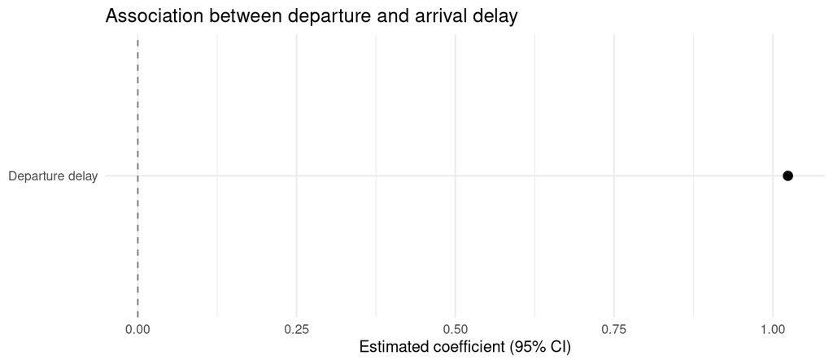

```r
modelsummary::modelplot(
  tidymodels_fit,
  coef_map = c("dep_delay" = "Departure delay")
) +
  ggplot2::geom_vline(
    xintercept = 0,
    linetype = "dashed",
    colour = "grey50"
  ) +
  ggplot2::labs(
    x = "Estimated coefficient (95% CI)",
    y = NULL,
    title = "Association between departure and arrival delay"
  ) +
  ggplot2::theme_minimal()
```

What does this tell us? The model uses a multiple of the departure delay when predicting the arrival delay - indicating that a plane usually gets a bit more delayed during travel, although not by much.

Coefficient plots become even more useful when you you include multiple predictors or even use them to compare multiple models. Let’s try to include `distance` in our plot as well!

# Wrap-up

In theory, you do not need `tidymodels` to perform modeling in R - and as we have seen, the models do not care **how** they are fitted. However, the `tidymodels` collection of packages contains many packages that are especially useful when fitting more complex models including a lot of preprocessing (`recipes`), or running models on different data (`workflows`).

Additionally, `broom` makes it easier to inspect properties of a fitted model and `yardstick` can help you calculate many different type of evaluation metrics, without worrying about implementing the math yourself.

For more complex models, `tidymodels` also includes packages for tuning hyper-parameters and lots of other things…

# Further reading

- [Get Started with tidymodels](https://www.tidymodels.org/start/)
- [*Tidy Modeling with R*](https://www.tmwr.org/)
- [`broom` documentation](https://broom.tidymodels.org/)
- [`modelsummary` documentation](https://modelsummary.com/)

This script was drafted by [Linus Hagemann](https://linushagemann.de). Generative AI was used to scaffold an initial draft that was comprehensively checked and edited. The script was improved by [Carol Sobral](https://github.com/cbsobral) and [Laia Domenech Burin](https://github.com/ldmnch).